# Introduction to data science in R, Lesson 7: Introduction to ggplot

## Exercise Seven:

> Modify the density plot you created in Exercise Six. Use `scale_fill_manual` to set custom fill colors.

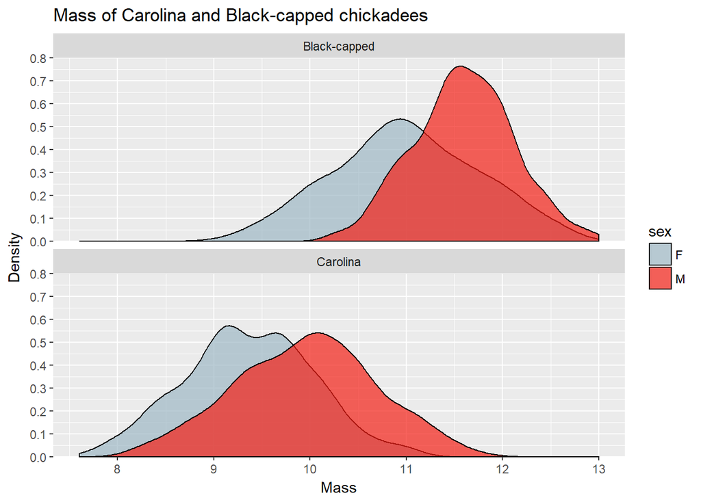

> ```r
> # Colors for massDensity:
>
> massDensity +
>   scale_y_continuous(expand = c(0, 0),
>                      limits = c(0, 0.8),
>                      breaks = seq(0, 0.8, by = 0.1)) +
>   scale_fill_manual(values = zPalette)
> ```

## Legends

Legends, also called **guides** can be rather cumbersome. I suggest making any modifications to legend items, with exception to a legend title, to the data frame being plotted (the piping method described above). For example, we can use piping to modify the legend of the histogram as follows:

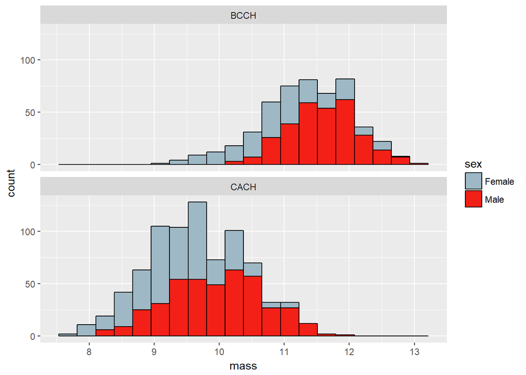

```r
birdMeasures %>%
  filter(spp %in% c('BCCH', 'CACH')) %>%
  mutate(sex = factor(sex,
                      labels = c('Female','Male'))) %>%
  ggplot(aes(x = mass)) +
  geom_histogram(aes(fill = sex),
                 bins = 20,
                 color = 'black') +
  facet_wrap(~spp, nrow = 2) +
  scale_fill_manual(values = c('#9EB8C5', '#F32017'))
```

An alternative to the piping method is to modify the `scale_fill_manual` function, where the fill colors were defined. Here, we can set a new legend `name` and the `labels`:

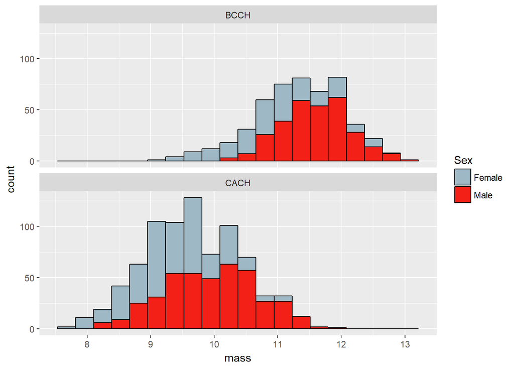

```r
birdMeasures %>%
  filter(spp %in% c('BCCH', 'CACH')) %>%
  ggplot(aes(x = mass)) +
  geom_histogram(aes(fill = sex),
                 bins = 20,
                 color = 'black') +
  facet_wrap(~spp, nrow = 2) +
  scale_fill_manual(values = c('#9EB8C5', '#F32017'),
                    name = 'Sex',
                    labels = c('Female', 'Male'))
```

## Exercise Eight:

> Modify the density plot you created in Exercise Seven. Use `scale_fill_manual` to set the legend title and labels.

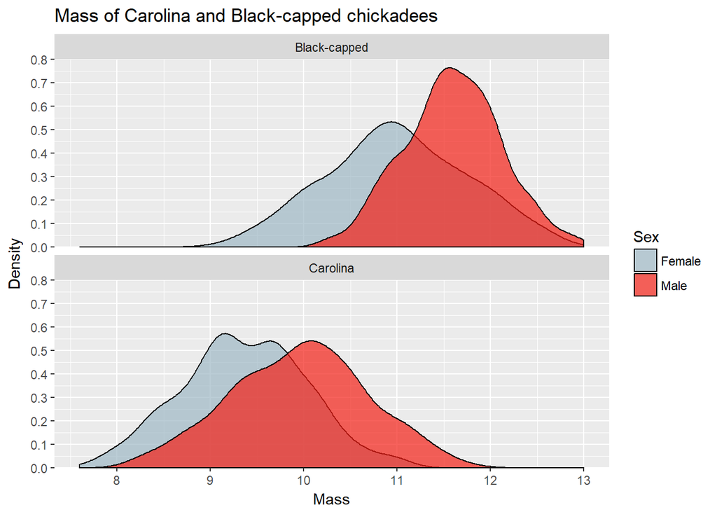

> ```r
> # Colors for massDensity:
> massDensity +
>   scale_y_continuous(expand = c(0, 0),
>                      limits = c(0, 0.8),
>                      breaks = seq(0, 0.8, by = 0.1)) +
>   scale_fill_manual(values = zPalette,
>                     name = 'Sex',
>                     labels = c('Female', 'Male'))
> ```

## Themes

Plots go from functional to publishable only once you set custom **themes**. Themes describe how each of the elements of a plot looks. Code tends to get very long very quickly when you start playing with themes, so this is a good time to assign a name your current plot.

The bar plot:

```r
barplot2Theme <- birdCaptures_basicPlot +
  scale_y_continuous(expand = c(0, 0),
                     limits = c(0, 1500))
```

The histogram plot:

```r
histogram2Theme <- birdMeasures %>%
  filter(spp %in% c('BCCH', 'CACH')) %>%
  ggplot(aes(x = mass)) +
  geom_histogram(aes(fill = sex),
                 bins = 20,
                 color = 'black') +
  facet_wrap(~spp, nrow = 2) +
  scale_fill_manual(values = c('#9EB8C5', '#F32017'),
                    name = 'Sex',
                    labels = c('Female', 'Male'))
```

```r
# Colors for massDensity:
density2Theme <- massDensity +
  scale_y_continuous(expand = c(0, 0),
                     limits = c(0, 0.8),
                     breaks = seq(0, 0.8, by = 0.1)) +
  scale_fill_manual(values = zPalette,
                    name = 'Sex',
                    labels = c('Female', 'Male'))
```